# Project: Investigate Soccer Dataset

- Introduction
- Data Wrangling
- Exploratory Data Analysis
- Conclusions

### Description

This soccer database comes from Kaggle and is well suited for data analysis and machine learning. It contains data for soccer matches, players, and teams from several European countries from 2008 to 2016. This dataset is quite extensive.

The database is stored in a SQLite database. The database files were accessed using software like DB Browser. This dataset helped to get good practice with SQL joins.

### Objective

Analysis of sports data. Explore the dataset and extract insights from the data. Use the analysis to answer the following questions:

1. Explore the dataset and extract insights using Exploratory Data Analysis.
2. What teams improved the most over the time period?
3. Which players had the most penalties?
4. How many matches was played per season?
5. Which Goalkeeper is likely to keep clean sheets?
6. Which Player is more likely to convert a set piece?
7. What condition is a team likely to score a goal?

## Introduction

> **Tip**: This analysis was conduted on majorly 5 tables (Match, League, Team, Player, Player Attributes) for this project. .

## References

- https://www.kaggle.com/hugomathien/soccer? for better understanding of the dataset
- https://pandas.pydata.org/pandas-docs/stable/reference/frame.html for pandas documentation
- https://stackoverflow.com/ in other cases when needed help

### Import necessary libraries

```python
# import libraries for data manipulation
import pandas as pd
import numpy as np

# import libraries for data visualization
import matplotlib.pyplot as plt
import seaborn as sns

# import library to access the database
import sqlite3 as sql


pd.set_option("display.max_columns", None) # to display all columns
```

## Data Wrangling

#### Understanding the structure of the data

The data is stored in a database. I used the library sqlite to access the tables in the database and used Pandas for data cleaning

```python
# connect to a database

db = sql.connect('database.sqlite')
```

```python
# check all tables

db_tables = pd.read_sql("SELECT name FROM sqlite_master WHERE type= 'table'", db)
db_tables
```

|  | name |
| --- | --- |
| 0 | sqlite_sequence |
| 1 | Player_Attributes |
| 2 | Player |
| 3 | Match |
| 4 | League |
| 5 | Country |
| 6 | Team |
| 7 | Team_Attributes |

#### Observation:

- There are 7 tables in the database. I will analyse each table to better understand the variables.

### Read csv files extracted from the database

### Player

```python
df_player = pd.read_sql_query('select * from Player', db)

df_player.head()
```

|  | id | player_api_id | player_name | player_fifa_api_id | birthday | height | weight |
| --- | --- | --- | --- | --- | --- | --- | --- |
| 0 | 1 | 505942 | Aaron Appindangoye | 218353 | 1992-02-29 00:00:00 | 182.88 | 187 |
| 1 | 2 | 155782 | Aaron Cresswell | 189615 | 1989-12-15 00:00:00 | 170.18 | 146 |
| 2 | 3 | 162549 | Aaron Doran | 186170 | 1991-05-13 00:00:00 | 170.18 | 163 |
| 3 | 4 | 30572 | Aaron Galindo | 140161 | 1982-05-08 00:00:00 | 182.88 | 198 |
| 4 | 5 | 23780 | Aaron Hughes | 17725 | 1979-11-08 00:00:00 | 182.88 | 154 |

#### Data Preprocessing

- Check the shape
- check the data information
- lets modify the birthday column in date-time format

```python
df_player.shape
```

```
(11060, 7)
```

```python
df_player.info()
```

```
<class 'pandas.core.frame.DataFrame'>
RangeIndex: 11060 entries, 0 to 11059
Data columns (total 7 columns):
 #   Column              Non-Null Count  Dtype
---  ------              --------------  -----
 0   id                  11060 non-null  int64
 1   player_api_id       11060 non-null  int64
 2   player_name         11060 non-null  object
 3   player_fifa_api_id  11060 non-null  int64
 4   birthday            11060 non-null  object
 5   height              11060 non-null  float64
 6   weight              11060 non-null  int64
dtypes: float64(1), int64(4), object(2)
memory usage: 605.0+ KB
```

```python
df_player['player_name'] = df_player.player_name.astype('category')
df_player['birthday'] = pd.to_datetime(df_player['birthday'])
```

```python
df_player.describe().T
```

|  | count | mean | std | min | 25% | 50% | 75% | max |
| --- | --- | --- | --- | --- | --- | --- | --- | --- |
| id | 11060.0 | 5537.511392 | 3197.692647 | 1.00 | 2767.75 | 5536.50 | 8306.25 | 11075.00 |
| player_api_id | 11060.0 | 156582.427215 | 160713.700624 | 2625.00 | 35555.50 | 96619.50 | 212470.50 | 750584.00 |
| player_fifa_api_id | 11060.0 | 165664.910488 | 58649.928360 | 2.00 | 151889.50 | 184671.00 | 203883.25 | 234141.00 |
| height | 11060.0 | 181.867445 | 6.369201 | 157.48 | 177.80 | 182.88 | 185.42 | 208.28 |
| weight | 11060.0 | 168.380289 | 14.990217 | 117.00 | 159.00 | 168.00 | 179.00 | 243.00 |

```python
df_player.describe(exclude="number", datetime_is_numeric=True).T
```

|  | count | unique | top | freq | mean | min | 25% | 50% | 75% | max |
| --- | --- | --- | --- | --- | --- | --- | --- | --- | --- | --- |
| player_name | 11060 | 10848 | Danilo | 7 | NaT | NaT | NaT | NaT | NaT | NaT |
| birthday | 11060 | NaN | NaN | NaN | 1987-02-03 21:19:20.072332800 | 1967-01-23 | 1983-03-17 | 1987-07-08 | 1991-04-12 | 1999-04-24 |

#### Observation

```python
# Extracting date parts from birthday

df_player['birth_year'] = df_player.birthday.dt.year
df_player['birth_month'] = df_player.birthday.dt.month_name()
df_player['birth_day'] = df_player.birthday.dt.day
df_player['birth_weekday'] = df_player.birthday.dt.day_name()
```

```python
df_player.head()
```

|  | id | player_api_id | player_name | player_fifa_api_id | birthday | height | weight | birth_year | birth_month | birth_day | birth_weekday |
| --- | --- | --- | --- | --- | --- | --- | --- | --- | --- | --- | --- |
| 0 | 1 | 505942 | Aaron Appindangoye | 218353 | 1992-02-29 | 182.88 | 187 | 1992 | February | 29 | Saturday |
| 1 | 2 | 155782 | Aaron Cresswell | 189615 | 1989-12-15 | 170.18 | 146 | 1989 | December | 15 | Friday |
| 2 | 3 | 162549 | Aaron Doran | 186170 | 1991-05-13 | 170.18 | 163 | 1991 | May | 13 | Monday |
| 3 | 4 | 30572 | Aaron Galindo | 140161 | 1982-05-08 | 182.88 | 198 | 1982 | May | 8 | Saturday |
| 4 | 5 | 23780 | Aaron Hughes | 17725 | 1979-11-08 | 182.88 | 154 | 1979 | November | 8 | Thursday |

```python
df_player.drop('birthday', axis= 1, inplace = True)
```

```python
df_player['year'] = df_player.birth_year.astype('category')
df_player['birth_month'] = df_player.birth_month.astype('category')
```

```python
pd_player = pd.read_csv("Player.csv")
pd_player.head()
```

|  | id | player_api_id | player_name | player_fifa_api_id | birthday | height | weight |
| --- | --- | --- | --- | --- | --- | --- | --- |
| 0 | 1 | 505942 | Aaron Appindangoye | 218353 | 1992-02-29 00:00:00 | 182.88 | 187 |
| 1 | 2 | 155782 | Aaron Cresswell | 189615 | 1989-12-15 00:00:00 | 170.18 | 146 |
| 2 | 3 | 162549 | Aaron Doran | 186170 | 1991-05-13 00:00:00 | 170.18 | 163 |
| 3 | 4 | 30572 | Aaron Galindo | 140161 | 1982-05-08 00:00:00 | 182.88 | 198 |
| 4 | 5 | 23780 | Aaron Hughes | 17725 | 1979-11-08 00:00:00 | 182.88 | 154 |

```python
df_player.isnull().sum()
```

```
id                    0
player_api_id         0
player_name           0
player_fifa_api_id    0
height                0
weight                0
birth_year            0
birth_month           0
birth_day             0
birth_weekday         0
year                  0
dtype: int64
```

```python
df_player.duplicated().sum()
```

```
0
```

#### Player_Attributes

```python
df_player_attr = pd.read_sql_query('select * from Player_attributes', db)
df_player_attr.head()
```

|  | id | player_fifa_api_id | player_api_id | date | overall_rating | potential | preferred_foot | attacking_work_rate | defensive_work_rate | crossing | finishing | heading_accuracy | short_passing | volleys | dribbling | curve | free_kick_accuracy | long_passing | ball_control | acceleration | sprint_speed | agility | reactions | balance | shot_power | jumping | stamina | strength | long_shots | … |
| --- | --- | --- | --- | --- | --- | --- | --- | --- | --- | --- | --- | --- | --- | --- | --- | --- | --- | --- | --- | --- | --- | --- | --- | --- | --- | --- | --- | --- | --- | --- |
| 0 | 1 | 218353 | 505942 | 2016-02-18 00:00:00 | 67.0 | 71.0 | right | medium | medium | 49.0 | 44.0 | 71.0 | 61.0 | 44.0 | 51.0 | 45.0 | 39.0 | 64.0 | 49.0 | 60.0 | 64.0 | 59.0 | 47.0 | 65.0 | 55.0 | 58.0 | 54.0 | 76.0 | 35.0 | … |
| 1 | 2 | 218353 | 505942 | 2015-11-19 00:00:00 | 67.0 | 71.0 | right | medium | medium | 49.0 | 44.0 | 71.0 | 61.0 | 44.0 | 51.0 | 45.0 | 39.0 | 64.0 | 49.0 | 60.0 | 64.0 | 59.0 | 47.0 | 65.0 | 55.0 | 58.0 | 54.0 | 76.0 | 35.0 | … |
| 2 | 3 | 218353 | 505942 | 2015-09-21 00:00:00 | 62.0 | 66.0 | right | medium | medium | 49.0 | 44.0 | 71.0 | 61.0 | 44.0 | 51.0 | 45.0 | 39.0 | 64.0 | 49.0 | 60.0 | 64.0 | 59.0 | 47.0 | 65.0 | 55.0 | 58.0 | 54.0 | 76.0 | 35.0 | … |
| 3 | 4 | 218353 | 505942 | 2015-03-20 00:00:00 | 61.0 | 65.0 | right | medium | medium | 48.0 | 43.0 | 70.0 | 60.0 | 43.0 | 50.0 | 44.0 | 38.0 | 63.0 | 48.0 | 60.0 | 64.0 | 59.0 | 46.0 | 65.0 | 54.0 | 58.0 | 54.0 | 76.0 | 34.0 | … |
| 4 | 5 | 218353 | 505942 | 2007-02-22 00:00:00 | 61.0 | 65.0 | right | medium | medium | 48.0 | 43.0 | 70.0 | 60.0 | 43.0 | 50.0 | 44.0 | 38.0 | 63.0 | 48.0 | 60.0 | 64.0 | 59.0 | 46.0 | 65.0 | 54.0 | 58.0 | 54.0 | 76.0 | 34.0 | … |

#### Data Preprocessing

- Check the shape
- check the data information
- check for null values
- check for duplicates

```python
df_player_attr.shape
```

```
(183978, 42)
```

```python
df_player_attr.isnull().sum()
```

```
id                        0
player_fifa_api_id        0
player_api_id             0
date                      0
overall_rating          836
potential               836
preferred_foot          836
attacking_work_rate    3230
defensive_work_rate     836
crossing                836
finishing               836
heading_accuracy        836
short_passing           836
volleys                2713
dribbling               836
curve                  2713
free_kick_accuracy      836
long_passing            836
ball_control            836
acceleration            836
sprint_speed            836
agility                2713
reactions               836
balance                2713
shot_power              836
jumping                2713
stamina                 836
strength                836
long_shots              836
aggression              836
interceptions           836
positioning             836
vision                 2713
penalties               836
marking                 836
standing_tackle         836
sliding_tackle         2713
gk_diving               836
gk_handling             836
gk_kicking              836
gk_positioning          836
gk_reflexes             836
dtype: int64
```

#### Observation

- There are a lot of missing values, I can drop them or fill them with median or mean values

```python
df_player_attr.duplicated().sum()
```

```
0
```

### Data Cleaning : Player and Attributes Table

### Merge Player and Player attributes data

In the team attributes table, there is one foreign key (i.e. player_api_id). I'll apply a merge operation over the Player table later on. This table is so essential to find out interesting statistics about players performance over the years.

```python
df_player_att = df_player_attr.merge(df_player, left_on='player_api_id', right_on='player_api_id')
```

```python
df_player_att.head()
```

|  | id_x | player_fifa_api_id_x | player_api_id | date | overall_rating | potential | preferred_foot | attacking_work_rate | defensive_work_rate | crossing | finishing | heading_accuracy | short_passing | volleys | dribbling | curve | free_kick_accuracy | long_passing | ball_control | acceleration | sprint_speed | agility | reactions | balance | shot_power | jumping | stamina | strength | long_shots | … |
| --- | --- | --- | --- | --- | --- | --- | --- | --- | --- | --- | --- | --- | --- | --- | --- | --- | --- | --- | --- | --- | --- | --- | --- | --- | --- | --- | --- | --- | --- | --- |
| 0 | 1 | 218353 | 505942 | 2016-02-18 00:00:00 | 67.0 | 71.0 | right | medium | medium | 49.0 | 44.0 | 71.0 | 61.0 | 44.0 | 51.0 | 45.0 | 39.0 | 64.0 | 49.0 | 60.0 | 64.0 | 59.0 | 47.0 | 65.0 | 55.0 | 58.0 | 54.0 | 76.0 | 35.0 | … |
| 1 | 2 | 218353 | 505942 | 2015-11-19 00:00:00 | 67.0 | 71.0 | right | medium | medium | 49.0 | 44.0 | 71.0 | 61.0 | 44.0 | 51.0 | 45.0 | 39.0 | 64.0 | 49.0 | 60.0 | 64.0 | 59.0 | 47.0 | 65.0 | 55.0 | 58.0 | 54.0 | 76.0 | 35.0 | … |
| 2 | 3 | 218353 | 505942 | 2015-09-21 00:00:00 | 62.0 | 66.0 | right | medium | medium | 49.0 | 44.0 | 71.0 | 61.0 | 44.0 | 51.0 | 45.0 | 39.0 | 64.0 | 49.0 | 60.0 | 64.0 | 59.0 | 47.0 | 65.0 | 55.0 | 58.0 | 54.0 | 76.0 | 35.0 | … |
| 3 | 4 | 218353 | 505942 | 2015-03-20 00:00:00 | 61.0 | 65.0 | right | medium | medium | 48.0 | 43.0 | 70.0 | 60.0 | 43.0 | 50.0 | 44.0 | 38.0 | 63.0 | 48.0 | 60.0 | 64.0 | 59.0 | 46.0 | 65.0 | 54.0 | 58.0 | 54.0 | 76.0 | 34.0 | … |
| 4 | 5 | 218353 | 505942 | 2007-02-22 00:00:00 | 61.0 | 65.0 | right | medium | medium | 48.0 | 43.0 | 70.0 | 60.0 | 43.0 | 50.0 | 44.0 | 38.0 | 63.0 | 48.0 | 60.0 | 64.0 | 59.0 | 46.0 | 65.0 | 54.0 | 58.0 | 54.0 | 76.0 | 34.0 | … |

```python
df_player_att.shape
```

```
(183978, 52)
```

```python
df_player_att.isnull().sum().sum() # check for null values
```

```
47301
```

```python
df_player_att.dropna(inplace=True) # drop null values
```

```python
df_player_att.describe()
```

|  | id_x | player_fifa_api_id_x | player_api_id | overall_rating | potential | crossing | finishing | heading_accuracy | short_passing | volleys | dribbling | curve | free_kick_accuracy | long_passing | ball_control | acceleration | sprint_speed | agility | reactions | balance | shot_power | jumping | stamina | strength | long_shots | aggression | interceptions | positioning | vision | … |
| --- | --- | --- | --- | --- | --- | --- | --- | --- | --- | --- | --- | --- | --- | --- | --- | --- | --- | --- | --- | --- | --- | --- | --- | --- | --- | --- | --- | --- | --- | --- |
| count | 180354.000000 | 180354.000000 | 180354.000000 | 180354.000000 | 180354.000000 | 180354.000000 | 180354.000000 | 180354.000000 | 180354.000000 | 180354.000000 | 180354.000000 | 180354.000000 | 180354.000000 | 180354.000000 | 180354.000000 | 180354.000000 | 180354.000000 | 180354.000000 | 180354.000000 | 180354.000000 | 180354.000000 | 180354.000000 | 180354.000000 | 180354.000000 | 180354.000000 | 180354.000000 | 180354.000000 | 180354.000000 | 180354.000000 | … |
| mean | 91995.886274 | 166822.125803 | 137653.145514 | 68.635317 | 73.479457 | 55.142071 | 49.962136 | 57.263476 | 62.486726 | 49.488927 | 59.265755 | 53.001408 | 49.392783 | 57.084578 | 63.453846 | 67.709405 | 68.101628 | 65.995082 | 66.148297 | 65.190082 | 61.866474 | 66.977333 | 67.053401 | 67.432477 | 53.387560 | 60.946217 | 51.897374 | 55.730730 | 57.868176 | … |
| std | 53092.657914 | 52821.443279 | 137599.735284 | 7.027950 | 6.581963 | 17.247231 | 19.041760 | 16.478716 | 14.172493 | 18.252319 | 17.741351 | 18.245476 | 17.820262 | 14.412035 | 15.187692 | 13.011580 | 12.585984 | 12.963670 | 9.145011 | 13.076192 | 16.129537 | 11.017828 | 13.200669 | 12.085131 | 18.370204 | 16.101618 | 19.483338 | 18.458218 | 15.152408 | … |
| min | 1.000000 | 2.000000 | 2625.000000 | 33.000000 | 39.000000 | 1.000000 | 1.000000 | 1.000000 | 3.000000 | 1.000000 | 1.000000 | 2.000000 | 1.000000 | 3.000000 | 5.000000 | 10.000000 | 12.000000 | 11.000000 | 17.000000 | 12.000000 | 2.000000 | 14.000000 | 10.000000 | 10.000000 | 1.000000 | 6.000000 | 1.000000 | 2.000000 | 1.000000 | … |
| 25% | 46074.250000 | 156616.000000 | 35451.000000 | 64.000000 | 69.000000 | 45.000000 | 34.000000 | 49.000000 | 57.000000 | 35.000000 | 52.000000 | 41.000000 | 36.000000 | 49.000000 | 59.000000 | 61.000000 | 62.000000 | 58.000000 | 61.000000 | 58.000000 | 54.000000 | 60.000000 | 61.000000 | 60.000000 | 41.000000 | 51.000000 | 34.000000 | 45.000000 | 49.000000 | … |
| 50% | 92003.500000 | 183792.000000 | 80291.000000 | 69.000000 | 74.000000 | 59.000000 | 53.000000 | 60.000000 | 65.000000 | 52.000000 | 64.000000 | 56.000000 | 50.000000 | 59.000000 | 67.000000 | 69.000000 | 69.000000 | 68.000000 | 67.000000 | 67.000000 | 66.000000 | 68.000000 | 69.000000 | 69.000000 | 58.000000 | 64.000000 | 56.000000 | 60.000000 | 60.000000 | … |
| 75% | 137935.750000 | 200138.000000 | 192841.000000 | 73.000000 | 78.000000 | 68.000000 | 65.000000 | 68.000000 | 72.000000 | 64.000000 | 72.000000 | 67.000000 | 63.000000 | 67.000000 | 73.000000 | 77.000000 | 77.000000 | 75.000000 | 72.000000 | 74.000000 | 73.000000 | 74.000000 | 76.000000 | 76.000000 | 67.000000 | 73.000000 | 68.000000 | 69.000000 | 69.000000 | … |
| max | 183978.000000 | 234141.000000 | 750584.000000 | 94.000000 | 97.000000 | 95.000000 | 97.000000 | 98.000000 | 97.000000 | 93.000000 | 97.000000 | 94.000000 | 97.000000 | 97.000000 | 97.000000 | 97.000000 | 97.000000 | 96.000000 | 96.000000 | 96.000000 | 97.000000 | 96.000000 | 96.000000 | 96.000000 | 96.000000 | 97.000000 | 96.000000 | 95.000000 | 97.000000 | … |

### Country

```python
df_countries = pd.read_sql_query("SELECT * FROM Country", db)
```

```python
df_countries.head()
```

|  | id | name |
| --- | --- | --- |
| 0 | 1 | Belgium |
| 1 | 1729 | England |
| 2 | 4769 | France |
| 3 | 7809 | Germany |
| 4 | 10257 | Italy |

#### Data Preprocessing

- Check the shape
- check the data information
- check for null values
- check for duplicates

```python
df_countries.shape
```

```
(11, 2)
```

```python
df_countries.duplicated().sum()
```

```
0
```

```python
df_countries.describe().T
```

|  | count | mean | std | min | 25% | 50% | 75% | max |
| --- | --- | --- | --- | --- | --- | --- | --- | --- |
| id | 11.0 | 12452.090909 | 8215.308472 | 1.0 | 6289.0 | 13274.0 | 18668.0 | 24558.0 |

#### Observation

- The **country** table has 2 columns, and there are 11 unique countries in this database.

### Leagues

```python
df_league = pd.read_sql('select * from League', db)
df_league.head()
```

|  | id | country_id | name |
| --- | --- | --- | --- |
| 0 | 1 | 1 | Belgium Jupiler League |
| 1 | 1729 | 1729 | England Premier League |
| 2 | 4769 | 4769 | France Ligue 1 |
| 3 | 7809 | 7809 | Germany 1. Bundesliga |
| 4 | 10257 | 10257 | Italy Serie A |

#### Data Preprocessing

- Check the shape
- check the data information
- check for null values
- check for duplicates

```python
df_league.shape
```

```
(11, 3)
```

```python
df_league.describe(exclude='number').T
```

|  | count | unique | top | freq |
| --- | --- | --- | --- | --- |
| name | 11 | 11 | Belgium Jupiler League | 1 |

#### Observation:

- There are 11 unique leagues with a primary key, country_id

### Teams

```python
df_team = pd.read_sql('select * from Team', db)
df_team.head()
```

|  | id | team_api_id | team_fifa_api_id | team_long_name | team_short_name |
| --- | --- | --- | --- | --- | --- |
| 0 | 1 | 9987 | 673.0 | KRC Genk | GEN |
| 1 | 2 | 9993 | 675.0 | Beerschot AC | BAC |
| 2 | 3 | 10000 | 15005.0 | SV Zulte-Waregem | ZUL |
| 3 | 4 | 9994 | 2007.0 | Sporting Lokeren | LOK |
| 4 | 5 | 9984 | 1750.0 | KSV Cercle Brugge | CEB |

#### Data Preprocessing

- Check the shape
- check the data information
- check for null values
- check for duplicates

```python
df_team.shape
```

```
(299, 5)
```

```python
df_team.describe(exclude = 'number').T
```

|  | count | unique | top | freq |
| --- | --- | --- | --- | --- |
| team_long_name | 299 | 296 | Widzew Łódź | 2 |
| team_short_name | 299 | 259 | GEN | 3 |

```python
df_team.duplicated().sum()
```

```
0
```

#### Observation

- There are 299 teams and 296 unique teams.
- The primary key used is team_api_id. This will be used for merging similar tables

### Team Attributes

```python
df_team_att = pd.read_sql('select * from Team_Attributes', db)
df_team_att.head()
```

|  | id | team_fifa_api_id | team_api_id | date | buildUpPlaySpeed | buildUpPlaySpeedClass | buildUpPlayDribbling | buildUpPlayDribblingClass | buildUpPlayPassing | buildUpPlayPassingClass | buildUpPlayPositioningClass | chanceCreationPassing | chanceCreationPassingClass | chanceCreationCrossing | chanceCreationCrossingClass | chanceCreationShooting | chanceCreationShootingClass | chanceCreationPositioningClass | defencePressure | defencePressureClass | defenceAggression | defenceAggressionClass | defenceTeamWidth | defenceTeamWidthClass | defenceDefenderLineClass |
| --- | --- | --- | --- | --- | --- | --- | --- | --- | --- | --- | --- | --- | --- | --- | --- | --- | --- | --- | --- | --- | --- | --- | --- | --- | --- |
| 0 | 1 | 434 | 9930 | 2010-02-22 00:00:00 | 60 | Balanced | NaN | Little | 50 | Mixed | Organised | 60 | Normal | 65 | Normal | 55 | Normal | Organised | 50 | Medium | 55 | Press | 45 | Normal | Cover |
| 1 | 2 | 434 | 9930 | 2014-09-19 00:00:00 | 52 | Balanced | 48.0 | Normal | 56 | Mixed | Organised | 54 | Normal | 63 | Normal | 64 | Normal | Organised | 47 | Medium | 44 | Press | 54 | Normal | Cover |
| 2 | 3 | 434 | 9930 | 2015-09-10 00:00:00 | 47 | Balanced | 41.0 | Normal | 54 | Mixed | Organised | 54 | Normal | 63 | Normal | 64 | Normal | Organised | 47 | Medium | 44 | Press | 54 | Normal | Cover |
| 3 | 4 | 77 | 8485 | 2010-02-22 00:00:00 | 70 | Fast | NaN | Little | 70 | Long | Organised | 70 | Risky | 70 | Lots | 70 | Lots | Organised | 60 | Medium | 70 | Double | 70 | Wide | Cover |
| 4 | 5 | 77 | 8485 | 2011-02-22 00:00:00 | 47 | Balanced | NaN | Little | 52 | Mixed | Organised | 53 | Normal | 48 | Normal | 52 | Normal | Organised | 47 | Medium | 47 | Press | 52 | Normal | Cover |

#### Data Preprocessing

- Check the shape
- check the data information
- check for null values
- check for duplicates

```python
df_team_att.shape
```

```
(1458, 25)
```

```python
df_team_att.info()
```

```
<class 'pandas.core.frame.DataFrame'>
RangeIndex: 1458 entries, 0 to 1457
Data columns (total 25 columns):
 #   Column                          Non-Null Count  Dtype
---  ------                          --------------  -----
 0   id                              1458 non-null   int64
 1   team_fifa_api_id                1458 non-null   int64
 2   team_api_id                     1458 non-null   int64
 3   date                            1458 non-null   object
 4   buildUpPlaySpeed                1458 non-null   int64
 5   buildUpPlaySpeedClass           1458 non-null   object
 6   buildUpPlayDribbling            489 non-null    float64
 7   buildUpPlayDribblingClass       1458 non-null   object
 8   buildUpPlayPassing              1458 non-null   int64
 9   buildUpPlayPassingClass         1458 non-null   object
```

[output cut: 17 more lines]

```python
# convert date to datetime datatype

df_team_att['date'] = pd.to_datetime(df_team_att['date'])
```

```python
df_team_att.isnull().sum()
```

```
id                                  0
team_fifa_api_id                    0
team_api_id                         0
date                                0
buildUpPlaySpeed                    0
buildUpPlaySpeedClass               0
buildUpPlayDribbling              969
buildUpPlayDribblingClass           0
buildUpPlayPassing                  0
buildUpPlayPassingClass             0
buildUpPlayPositioningClass         0
chanceCreationPassing               0
chanceCreationPassingClass          0
chanceCreationCrossing              0
chanceCreationCrossingClass         0
chanceCreationShooting              0
chanceCreationShootingClass         0
chanceCreationPositioningClass      0
defencePressure                     0
defencePressureClass                0
defenceAggression                   0
defenceAggressionClass              0
defenceTeamWidth                    0
defenceTeamWidthClass               0
defenceDefenderLineClass            0
dtype: int64
```

```python
df_team_att.duplicated().sum()
```

```
0
```

```python
# Extracting date parts from birthday

df_team_att['date_year'] = df_team_att.date.dt.year
df_team_att['date_month'] = df_team_att.date.dt.month
df_team_att['date_day'] = df_team_att.date.dt.day
df_player['date_day_name'] = df_team_att.date.dt.day_name()
```

#### Observation

- There are missing values in one of the features.
- The date column is converted to a datetime datatype.
- The foreign key is the team_api_id

### Matches

```python
df_matches = pd.read_sql("SELECT * FROM Match", db)
df_matches.head()
```

|  | id | country_id | league_id | season | stage | date | match_api_id | home_team_api_id | away_team_api_id | home_team_goal | away_team_goal | home_player_X1 | home_player_X2 | home_player_X3 | home_player_X4 | home_player_X5 | home_player_X6 | home_player_X7 | home_player_X8 | home_player_X9 | home_player_X10 | home_player_X11 | away_player_X1 | away_player_X2 | away_player_X3 | away_player_X4 | away_player_X5 | away_player_X6 | away_player_X7 | … |
| --- | --- | --- | --- | --- | --- | --- | --- | --- | --- | --- | --- | --- | --- | --- | --- | --- | --- | --- | --- | --- | --- | --- | --- | --- | --- | --- | --- | --- | --- | --- |
| 0 | 1 | 1 | 1 | 2008/2009 | 1 | 2008-08-17 00:00:00 | 492473 | 9987 | 9993 | 1 | 1 | NaN | NaN | NaN | NaN | NaN | NaN | NaN | NaN | NaN | NaN | NaN | NaN | NaN | NaN | NaN | NaN | NaN | NaN | … |
| 1 | 2 | 1 | 1 | 2008/2009 | 1 | 2008-08-16 00:00:00 | 492474 | 10000 | 9994 | 0 | 0 | NaN | NaN | NaN | NaN | NaN | NaN | NaN | NaN | NaN | NaN | NaN | NaN | NaN | NaN | NaN | NaN | NaN | NaN | … |
| 2 | 3 | 1 | 1 | 2008/2009 | 1 | 2008-08-16 00:00:00 | 492475 | 9984 | 8635 | 0 | 3 | NaN | NaN | NaN | NaN | NaN | NaN | NaN | NaN | NaN | NaN | NaN | NaN | NaN | NaN | NaN | NaN | NaN | NaN | … |
| 3 | 4 | 1 | 1 | 2008/2009 | 1 | 2008-08-17 00:00:00 | 492476 | 9991 | 9998 | 5 | 0 | NaN | NaN | NaN | NaN | NaN | NaN | NaN | NaN | NaN | NaN | NaN | NaN | NaN | NaN | NaN | NaN | NaN | NaN | … |
| 4 | 5 | 1 | 1 | 2008/2009 | 1 | 2008-08-16 00:00:00 | 492477 | 7947 | 9985 | 1 | 3 | NaN | NaN | NaN | NaN | NaN | NaN | NaN | NaN | NaN | NaN | NaN | NaN | NaN | NaN | NaN | NaN | NaN | NaN | … |

#### Data Preprocessing

- Check the shape
- check the data information
- check for null values
- check for duplicates

```python
df_matches.shape
```

```
(25979, 115)
```

```python
df_matches.duplicated().sum()
```

```
0
```

```python
df_matches.isnull().sum().sum()
```

```
407395
```

#### Observation

- There are a lot of missing values.
- There are 4 important id columns (i.e. country_id, league_id, home_team_api_id, and away_team_api_id) that could be used to merge other tables.

## DATA CLEANING

### Match Table

- Clean the Match table for further analysis

```python
# drop any columns that contains a missing value

df_matches.dropna(axis='columns', inplace=True)
```

```python
# check for null values

df_matches.isnull().sum().sum()
```

```
0
```

```python
df_matches.shape
```

```
(25979, 11)
```

```python
df_matches.info()
```

```
<class 'pandas.core.frame.DataFrame'>
RangeIndex: 25979 entries, 0 to 25978
Data columns (total 11 columns):
 #   Column            Non-Null Count  Dtype
---  ------            --------------  -----
 0   id                25979 non-null  int64
 1   country_id        25979 non-null  int64
 2   league_id         25979 non-null  int64
 3   season            25979 non-null  object
 4   stage             25979 non-null  int64
 5   date              25979 non-null  object
 6   match_api_id      25979 non-null  int64
 7   home_team_api_id  25979 non-null  int64
 8   away_team_api_id  25979 non-null  int64
 9   home_team_goal    25979 non-null  int64
 10  away_team_goal    25979 non-null  int64
dtypes: int64(9), object(2)
memory usage: 2.2+ MB
```

```python
# to change the column 'data' to datetime datatype

df_matches['date'] = pd.to_datetime(df_matches['date'])
```

```python
# add a year column

df_matches['year'] = df_matches['date'].dt.year
```

```python
df_matches.head()
```

|  | id | country_id | league_id | season | stage | date | match_api_id | home_team_api_id | away_team_api_id | home_team_goal | away_team_goal | year |
| --- | --- | --- | --- | --- | --- | --- | --- | --- | --- | --- | --- | --- |
| 0 | 1 | 1 | 1 | 2008/2009 | 1 | 2008-08-17 | 492473 | 9987 | 9993 | 1 | 1 | 2008 |
| 1 | 2 | 1 | 1 | 2008/2009 | 1 | 2008-08-16 | 492474 | 10000 | 9994 | 0 | 0 | 2008 |
| 2 | 3 | 1 | 1 | 2008/2009 | 1 | 2008-08-16 | 492475 | 9984 | 8635 | 0 | 3 | 2008 |
| 3 | 4 | 1 | 1 | 2008/2009 | 1 | 2008-08-17 | 492476 | 9991 | 9998 | 5 | 0 | 2008 |
| 4 | 5 | 1 | 1 | 2008/2009 | 1 | 2008-08-16 | 492477 | 7947 | 9985 | 1 | 3 | 2008 |

```python
df_matches.info()
```

```
<class 'pandas.core.frame.DataFrame'>
RangeIndex: 25979 entries, 0 to 25978
Data columns (total 12 columns):
 #   Column            Non-Null Count  Dtype
---  ------            --------------  -----
 0   id                25979 non-null  int64
 1   country_id        25979 non-null  int64
 2   league_id         25979 non-null  int64
 3   season            25979 non-null  object
 4   stage             25979 non-null  int64
 5   date              25979 non-null  datetime64[ns]
 6   match_api_id      25979 non-null  int64
 7   home_team_api_id  25979 non-null  int64
 8   away_team_api_id  25979 non-null  int64
 9   home_team_goal    25979 non-null  int64
 10  away_team_goal    25979 non-null  int64
 11  year              25979 non-null  int64
dtypes: datetime64[ns](1), int64(10), object(1)
memory usage: 2.4+ MB
```

## Merge Match Table and Country Table

```python
df_countries.head()
```

|  | id | name |
| --- | --- | --- |
| 0 | 1 | Belgium |
| 1 | 1729 | England |
| 2 | 4769 | France |
| 3 | 7809 | Germany |
| 4 | 10257 | Italy |

```python
# rename name to country_name and id to country_id
df_countries.rename(columns={'name' : 'country_name', 'id': 'country_id'}, inplace=True)
```

```python
df_countries.head()
```

|  | country_id | country_name |
| --- | --- | --- |
| 0 | 1 | Belgium |
| 1 | 1729 | England |
| 2 | 4769 | France |
| 3 | 7809 | Germany |
| 4 | 10257 | Italy |

```python
df_matches_copy = df_matches.copy #copy the matches table
```

```python
# apply inner merge with country table
df_matches = df_matches.merge(df_countries, how='inner', left_on='country_id', right_on='country_id')
```

```python
df_matches.head()
```

|  | id | country_id | league_id | season | stage | date | match_api_id | home_team_api_id | away_team_api_id | home_team_goal | away_team_goal | year | country_name |
| --- | --- | --- | --- | --- | --- | --- | --- | --- | --- | --- | --- | --- | --- |
| 0 | 1 | 1 | 1 | 2008/2009 | 1 | 2008-08-17 | 492473 | 9987 | 9993 | 1 | 1 | 2008 | Belgium |
| 1 | 2 | 1 | 1 | 2008/2009 | 1 | 2008-08-16 | 492474 | 10000 | 9994 | 0 | 0 | 2008 | Belgium |
| 2 | 3 | 1 | 1 | 2008/2009 | 1 | 2008-08-16 | 492475 | 9984 | 8635 | 0 | 3 | 2008 | Belgium |
| 3 | 4 | 1 | 1 | 2008/2009 | 1 | 2008-08-17 | 492476 | 9991 | 9998 | 5 | 0 | 2008 | Belgium |
| 4 | 5 | 1 | 1 | 2008/2009 | 1 | 2008-08-16 | 492477 | 7947 | 9985 | 1 | 3 | 2008 | Belgium |

### Merge Match Table and League Table

```python
df_league.head()
```

|  | id | country_id | name |
| --- | --- | --- | --- |
| 0 | 1 | 1 | Belgium Jupiler League |
| 1 | 1729 | 1729 | England Premier League |
| 2 | 4769 | 4769 | France Ligue 1 |
| 3 | 7809 | 7809 | Germany 1. Bundesliga |
| 4 | 10257 | 10257 | Italy Serie A |

```python
df_league_copy = df_league.copy()
```

```python
df_league_copy.rename(columns={'id':'league_id', 'name':'league_name'}, inplace = True)
```

```python
df_league_copy.head()
```

|  | league_id | country_id | league_name |
| --- | --- | --- | --- |
| 0 | 1 | 1 | Belgium Jupiler League |
| 1 | 1729 | 1729 | England Premier League |
| 2 | 4769 | 4769 | France Ligue 1 |
| 3 | 7809 | 7809 | Germany 1. Bundesliga |
| 4 | 10257 | 10257 | Italy Serie A |

```python
df_matches = df_matches.merge(df_league_copy, how = 'inner', left_on = 'league_id', right_on = 'league_id')
```

```python
df_matches.head()
```

|  | id | country_id_x | league_id | season | stage | date | match_api_id | home_team_api_id | away_team_api_id | home_team_goal | away_team_goal | year | country_name | country_id_y | league_name |
| --- | --- | --- | --- | --- | --- | --- | --- | --- | --- | --- | --- | --- | --- | --- | --- |
| 0 | 1 | 1 | 1 | 2008/2009 | 1 | 2008-08-17 | 492473 | 9987 | 9993 | 1 | 1 | 2008 | Belgium | 1 | Belgium Jupiler League |
| 1 | 2 | 1 | 1 | 2008/2009 | 1 | 2008-08-16 | 492474 | 10000 | 9994 | 0 | 0 | 2008 | Belgium | 1 | Belgium Jupiler League |
| 2 | 3 | 1 | 1 | 2008/2009 | 1 | 2008-08-16 | 492475 | 9984 | 8635 | 0 | 3 | 2008 | Belgium | 1 | Belgium Jupiler League |
| 3 | 4 | 1 | 1 | 2008/2009 | 1 | 2008-08-17 | 492476 | 9991 | 9998 | 5 | 0 | 2008 | Belgium | 1 | Belgium Jupiler League |
| 4 | 5 | 1 | 1 | 2008/2009 | 1 | 2008-08-16 | 492477 | 7947 | 9985 | 1 | 3 | 2008 | Belgium | 1 | Belgium Jupiler League |

```python
df_matches.drop(columns=['league_id', 'country_id_x', 'country_id_y'], inplace= True)
```

### Merge Match Table and Team Table

```python
df_team.head()
```

|  | id | team_api_id | team_fifa_api_id | team_long_name | team_short_name |
| --- | --- | --- | --- | --- | --- |
| 0 | 1 | 9987 | 673.0 | KRC Genk | GEN |
| 1 | 2 | 9993 | 675.0 | Beerschot AC | BAC |
| 2 | 3 | 10000 | 15005.0 | SV Zulte-Waregem | ZUL |
| 3 | 4 | 9994 | 2007.0 | Sporting Lokeren | LOK |
| 4 | 5 | 9984 | 1750.0 | KSV Cercle Brugge | CEB |

```python
df_copy_team = df_team.copy()
```

```python
# first merge for the home_team_id
df_matches = df_matches.merge(df_copy_team, how='inner', left_on='home_team_api_id', right_on='team_api_id')

df_matches.rename(columns={'team_long_name': 'home_team_name'}, inplace=True)

df_matches.drop(columns=['home_team_api_id', 'team_api_id'], axis=1, inplace=True)
```

```python
# second merge the away_team_id
df_matches = df_matches.merge(df_copy_team, how='left', left_on='away_team_api_id', right_on='team_api_id')

df_matches.rename(columns={'team_long_name': 'away_team_name'}, inplace=True)

df_matches.drop(columns=['team_api_id', 'away_team_api_id'], axis=1, inplace=True)
```

```python
df_matches.head()
```

|  | id_x | season | stage | date | match_api_id | home_team_goal | away_team_goal | year | country_name | league_name | id_y | team_fifa_api_id_x | home_team_name | team_short_name_x | id | team_fifa_api_id_y | away_team_name | team_short_name_y |
| --- | --- | --- | --- | --- | --- | --- | --- | --- | --- | --- | --- | --- | --- | --- | --- | --- | --- | --- |
| 0 | 1 | 2008/2009 | 1 | 2008-08-17 | 492473 | 1 | 1 | 2008 | Belgium | Belgium Jupiler League | 1 | 673.0 | KRC Genk | GEN | 2 | 675.0 | Beerschot AC | BAC |
| 1 | 29 | 2008/2009 | 12 | 2008-11-15 | 492583 | 1 | 1 | 2008 | Belgium | Belgium Jupiler League | 1 | 673.0 | KRC Genk | GEN | 13 | 546.0 | KSV Roeselare | ROS |
| 2 | 47 | 2008/2009 | 14 | 2008-11-29 | 492651 | 3 | 2 | 2008 | Belgium | Belgium Jupiler League | 1 | 673.0 | KRC Genk | GEN | 5 | 1750.0 | KSV Cercle Brugge | CEB |
| 3 | 65 | 2008/2009 | 16 | 2008-12-13 | 492713 | 1 | 0 | 2008 | Belgium | Belgium Jupiler League | 1 | 673.0 | KRC Genk | GEN | 18 | 670.0 | Sporting Charleroi | CHA |
| 4 | 94 | 2008/2009 | 19 | 2009-01-24 | 492805 | 2 | 0 | 2009 | Belgium | Belgium Jupiler League | 1 | 673.0 | KRC Genk | GEN | 8 | 1747.0 | RAEC Mons | MON |

#### Function to determine match outcome

```python
def match_outcome(r):
    home_score = r[0]
    away_score = r[1]
    home_team_name = r[2]
    away_team_name = r[3]

    if home_score > away_score:
        return 'Home'
    elif home_score < away_score:
        return 'Away'
    else:
        return 'Tie'

df_matches['match_outcome']  = df_matches[['home_team_goal', 'away_team_goal', 'home_team_name', 'away_team_name']].apply(match_outcome, axis=1)
```

```python
# drop some columns

df_matches.drop(['stage', 'match_api_id'], axis=1, inplace=True)
```

```python
df_matches.head()
```

|  | id_x | season | date | home_team_goal | away_team_goal | year | country_name | league_name | id_y | team_fifa_api_id_x | home_team_name | team_short_name_x | id | team_fifa_api_id_y | away_team_name | team_short_name_y | match_outcome |
| --- | --- | --- | --- | --- | --- | --- | --- | --- | --- | --- | --- | --- | --- | --- | --- | --- | --- |
| 0 | 1 | 2008/2009 | 2008-08-17 | 1 | 1 | 2008 | Belgium | Belgium Jupiler League | 1 | 673.0 | KRC Genk | GEN | 2 | 675.0 | Beerschot AC | BAC | Tie |
| 1 | 29 | 2008/2009 | 2008-11-15 | 1 | 1 | 2008 | Belgium | Belgium Jupiler League | 1 | 673.0 | KRC Genk | GEN | 13 | 546.0 | KSV Roeselare | ROS | Tie |
| 2 | 47 | 2008/2009 | 2008-11-29 | 3 | 2 | 2008 | Belgium | Belgium Jupiler League | 1 | 673.0 | KRC Genk | GEN | 5 | 1750.0 | KSV Cercle Brugge | CEB | Home |
| 3 | 65 | 2008/2009 | 2008-12-13 | 1 | 0 | 2008 | Belgium | Belgium Jupiler League | 1 | 673.0 | KRC Genk | GEN | 18 | 670.0 | Sporting Charleroi | CHA | Home |
| 4 | 94 | 2008/2009 | 2009-01-24 | 2 | 0 | 2009 | Belgium | Belgium Jupiler League | 1 | 673.0 | KRC Genk | GEN | 8 | 1747.0 | RAEC Mons | MON | Home |

```python
# rename 2 columns because after merging two tables

df_matches.rename(columns={'id_x': 'id', 'team_fifa_api_id_x': 'team_fifa_api_id',
                           'team_fifa_api_id_y': 'team_fifa_api_id',
                          'team_short_name_x': 'team_short_name',
                          'team_short_name_y': 'team_short_name_y',
                          },inplace=True)
```

```python
df_matches.to_csv('matches_clean.csv', index=False)
```

### Data Cleaning: Team And Attibutes table

```python
df_team.head()
```

|  | id | team_api_id | team_fifa_api_id | team_long_name | team_short_name |
| --- | --- | --- | --- | --- | --- |
| 0 | 1 | 9987 | 673.0 | KRC Genk | GEN |
| 1 | 2 | 9993 | 675.0 | Beerschot AC | BAC |
| 2 | 3 | 10000 | 15005.0 | SV Zulte-Waregem | ZUL |
| 3 | 4 | 9994 | 2007.0 | Sporting Lokeren | LOK |
| 4 | 5 | 9984 | 1750.0 | KSV Cercle Brugge | CEB |

```python
df_team.nunique()
```

```
id                  299
team_api_id         299
team_fifa_api_id    285
team_long_name      296
team_short_name     259
dtype: int64
```

```python
df_duplicate = df_team.team_long_name.value_counts()[:10]
```

```python
df_duplicate.duplicated().sum()
```

```
8
```

```python
# find duplicated teams by club name
df_team.team_long_name.value_counts()[df_team.team_long_name.value_counts() >= 2]
```

```
Widzew Łódź             2
Royal Excel Mouscron    2
Polonia Bytom           2
Name: team_long_name, dtype: int64
```

```python
df_team.query('team_long_name == "Royal Excel Mouscron"')
```

|  | id | team_api_id | team_fifa_api_id | team_long_name | team_short_name |
| --- | --- | --- | --- | --- | --- |
| 15 | 16 | 9996 | 111560.0 | Royal Excel Mouscron | MOU |
| 24 | 2510 | 274581 | 111560.0 | Royal Excel Mouscron | MOP |

```python
df_team.query('team_long_name == "Polonia Bytom"')
```

|  | id | team_api_id | team_fifa_api_id | team_long_name | team_short_name |
| --- | --- | --- | --- | --- | --- |
| 182 | 31444 | 8031 | 111429.0 | Polonia Bytom | POB |
| 183 | 31445 | 8020 | 111429.0 | Polonia Bytom | GOR |

```python
df_team.query('team_long_name == "Widzew Łódź"')
```

|  | id | team_api_id | team_fifa_api_id | team_long_name | team_short_name |
| --- | --- | --- | --- | --- | --- |
| 189 | 31451 | 8244 | 301.0 | Widzew Łódź | LOD |
| 199 | 32409 | 8024 | 301.0 | Widzew Łódź | WID |

```python
# drop the rows by index id

df_team.drop(index=[24, 183, 199], inplace=True)
```

```python
# merge using inner join
df_team_att_merged = df_team_att.merge(df_team, left_on='team_api_id', right_on='team_api_id')
```

```python
df_team_att_merged.head()
```

|  | id_x | team_fifa_api_id_x | team_api_id | date | buildUpPlaySpeed | buildUpPlaySpeedClass | buildUpPlayDribbling | buildUpPlayDribblingClass | buildUpPlayPassing | buildUpPlayPassingClass | buildUpPlayPositioningClass | chanceCreationPassing | chanceCreationPassingClass | chanceCreationCrossing | chanceCreationCrossingClass | chanceCreationShooting | chanceCreationShootingClass | chanceCreationPositioningClass | defencePressure | defencePressureClass | defenceAggression | defenceAggressionClass | defenceTeamWidth | defenceTeamWidthClass | defenceDefenderLineClass | date_year | date_month | date_day | id_y | … |
| --- | --- | --- | --- | --- | --- | --- | --- | --- | --- | --- | --- | --- | --- | --- | --- | --- | --- | --- | --- | --- | --- | --- | --- | --- | --- | --- | --- | --- | --- | --- |
| 0 | 1 | 434 | 9930 | 2010-02-22 | 60 | Balanced | NaN | Little | 50 | Mixed | Organised | 60 | Normal | 65 | Normal | 55 | Normal | Organised | 50 | Medium | 55 | Press | 45 | Normal | Cover | 2010 | 2 | 22 | 49119 | … |
| 1 | 2 | 434 | 9930 | 2014-09-19 | 52 | Balanced | 48.0 | Normal | 56 | Mixed | Organised | 54 | Normal | 63 | Normal | 64 | Normal | Organised | 47 | Medium | 44 | Press | 54 | Normal | Cover | 2014 | 9 | 19 | 49119 | … |
| 2 | 3 | 434 | 9930 | 2015-09-10 | 47 | Balanced | 41.0 | Normal | 54 | Mixed | Organised | 54 | Normal | 63 | Normal | 64 | Normal | Organised | 47 | Medium | 44 | Press | 54 | Normal | Cover | 2015 | 9 | 10 | 49119 | … |
| 3 | 4 | 77 | 8485 | 2010-02-22 | 70 | Fast | NaN | Little | 70 | Long | Organised | 70 | Risky | 70 | Lots | 70 | Lots | Organised | 60 | Medium | 70 | Double | 70 | Wide | Cover | 2010 | 2 | 22 | 39393 | … |
| 4 | 5 | 77 | 8485 | 2011-02-22 | 47 | Balanced | NaN | Little | 52 | Mixed | Organised | 53 | Normal | 48 | Normal | 52 | Normal | Organised | 47 | Medium | 47 | Press | 52 | Normal | Cover | 2011 | 2 | 22 | 39393 | … |

```python
# rename 2 columns because after merging two tables

df_team_att_merged.rename(columns={'id_x': 'id', 'team_fifa_api_id_x': 'team_fifa_api_id'}, inplace=True)
```

```python
df_team_att_merged.head()
```

|  | id | team_fifa_api_id | team_api_id | date | buildUpPlaySpeed | buildUpPlaySpeedClass | buildUpPlayDribbling | buildUpPlayDribblingClass | buildUpPlayPassing | buildUpPlayPassingClass | buildUpPlayPositioningClass | chanceCreationPassing | chanceCreationPassingClass | chanceCreationCrossing | chanceCreationCrossingClass | chanceCreationShooting | chanceCreationShootingClass | chanceCreationPositioningClass | defencePressure | defencePressureClass | defenceAggression | defenceAggressionClass | defenceTeamWidth | defenceTeamWidthClass | defenceDefenderLineClass | date_year | date_month | date_day | id_y | … |
| --- | --- | --- | --- | --- | --- | --- | --- | --- | --- | --- | --- | --- | --- | --- | --- | --- | --- | --- | --- | --- | --- | --- | --- | --- | --- | --- | --- | --- | --- | --- |
| 0 | 1 | 434 | 9930 | 2010-02-22 | 60 | Balanced | NaN | Little | 50 | Mixed | Organised | 60 | Normal | 65 | Normal | 55 | Normal | Organised | 50 | Medium | 55 | Press | 45 | Normal | Cover | 2010 | 2 | 22 | 49119 | … |
| 1 | 2 | 434 | 9930 | 2014-09-19 | 52 | Balanced | 48.0 | Normal | 56 | Mixed | Organised | 54 | Normal | 63 | Normal | 64 | Normal | Organised | 47 | Medium | 44 | Press | 54 | Normal | Cover | 2014 | 9 | 19 | 49119 | … |
| 2 | 3 | 434 | 9930 | 2015-09-10 | 47 | Balanced | 41.0 | Normal | 54 | Mixed | Organised | 54 | Normal | 63 | Normal | 64 | Normal | Organised | 47 | Medium | 44 | Press | 54 | Normal | Cover | 2015 | 9 | 10 | 49119 | … |
| 3 | 4 | 77 | 8485 | 2010-02-22 | 70 | Fast | NaN | Little | 70 | Long | Organised | 70 | Risky | 70 | Lots | 70 | Lots | Organised | 60 | Medium | 70 | Double | 70 | Wide | Cover | 2010 | 2 | 22 | 39393 | … |
| 4 | 5 | 77 | 8485 | 2011-02-22 | 47 | Balanced | NaN | Little | 52 | Mixed | Organised | 53 | Normal | 48 | Normal | 52 | Normal | Organised | 47 | Medium | 47 | Press | 52 | Normal | Cover | 2011 | 2 | 22 | 39393 | … |

```python
# drop 3 columns that we used for merging
df_team_att_merged.drop(columns=['team_fifa_api_id', 'id_y', 'team_fifa_api_id_y'], inplace=True)
```

```python
df_team_att_merged.info()
```

```
<class 'pandas.core.frame.DataFrame'>
Int64Index: 1451 entries, 0 to 1450
Data columns (total 29 columns):
 #   Column                          Non-Null Count  Dtype
---  ------                          --------------  -----
 0   id                              1451 non-null   int64
 1   team_api_id                     1451 non-null   int64
 2   date                            1451 non-null   datetime64[ns]
 3   buildUpPlaySpeed                1451 non-null   int64
 4   buildUpPlaySpeedClass           1451 non-null   object
 5   buildUpPlayDribbling            487 non-null    float64
 6   buildUpPlayDribblingClass       1451 non-null   object
 7   buildUpPlayPassing              1451 non-null   int64
 8   buildUpPlayPassingClass         1451 non-null   object
 9   buildUpPlayPositioningClass     1451 non-null   object
```

[output cut: 21 more lines]

```python
df_team_att_merged['date'] = pd.to_datetime(df_team_att_merged['date'])
```

```python
df_team_att_merged['year'] = df_team_att_merged['date'].dt.year
```

```python
#df_team_att_merged.drop("date",axis=1,inplace= True)
```

```python
df_team_att_merged.to_csv('team_attributes_edited.csv', index=False)
```

## Exploratory Data Analysis

### Research Question 1 (What teams improved the most over the time period in terms of goal scored?)

I selected year 2008, and 2011 to compare the details of the teams. In order words, using these years we analyze what teams improved the most.

```python
df_matches_clean = pd.read_csv("matches_clean.csv")
df_matches_clean.head()
```

|  | id | season | date | home_team_goal | away_team_goal | year | country_name | league_name | id_y | team_fifa_api_id | home_team_name | team_short_name | id.1 | team_fifa_api_id.1 | away_team_name | team_short_name_y | match_outcome |
| --- | --- | --- | --- | --- | --- | --- | --- | --- | --- | --- | --- | --- | --- | --- | --- | --- | --- |
| 0 | 1 | 2008/2009 | 2008-08-17 | 1 | 1 | 2008 | Belgium | Belgium Jupiler League | 1 | 673.0 | KRC Genk | GEN | 2 | 675.0 | Beerschot AC | BAC | Tie |
| 1 | 29 | 2008/2009 | 2008-11-15 | 1 | 1 | 2008 | Belgium | Belgium Jupiler League | 1 | 673.0 | KRC Genk | GEN | 13 | 546.0 | KSV Roeselare | ROS | Tie |
| 2 | 47 | 2008/2009 | 2008-11-29 | 3 | 2 | 2008 | Belgium | Belgium Jupiler League | 1 | 673.0 | KRC Genk | GEN | 5 | 1750.0 | KSV Cercle Brugge | CEB | Home |
| 3 | 65 | 2008/2009 | 2008-12-13 | 1 | 0 | 2008 | Belgium | Belgium Jupiler League | 1 | 673.0 | KRC Genk | GEN | 18 | 670.0 | Sporting Charleroi | CHA | Home |
| 4 | 94 | 2008/2009 | 2009-01-24 | 2 | 0 | 2009 | Belgium | Belgium Jupiler League | 1 | 673.0 | KRC Genk | GEN | 8 | 1747.0 | RAEC Mons | MON | Home |

```python
# number of unique years in the table
years = df_matches_clean.year.unique()
years
```

```
array([2008, 2009, 2010, 2011, 2012, 2013, 2014, 2015, 2016], dtype=int64)
```

```python
#number of away teams
len(df_matches_clean.away_team_name.unique())
```

```
296
```

```python
# number of home teams
len(df_matches_clean.home_team_name.unique())
```

```
296
```

#### Use statistical analysis to estimate

```python
df_match_2008 = df_matches_clean.query('year == 2008')

df_match_2011 = df_matches_clean.query('year == 2011')

df_match_2011_away = df_match_2011.groupby(['away_team_name'])['away_team_goal'].mean() # average away team goals

df_match_2011_home = df_match_2011.groupby(['home_team_name'])['home_team_goal'].mean() # average home team goals

df_match_2008_away = df_match_2008.groupby(['away_team_name'])['away_team_goal'].mean()

df_match_2008_home = df_match_2008.groupby(['home_team_name'])['home_team_goal'].mean()

df_match_total_2011 = (df_match_2011_away + df_match_2011_home) / 2 #average of away and home goals in 2011

df_match_total_2008 = (df_match_2008_away + df_match_2008_home) / 2 # average of away and home goals in 2008

diff_match_2011_2008 = df_match_total_2011 - df_match_total_2008
```

```python
diff_match_2011_2008
```

```
away_team_name
1. FC Kaiserslautern             NaN
1. FC Köln                  0.524306
1. FC Nürnberg                   NaN
1. FSV Mainz 05                  NaN
AC Ajaccio                       NaN
                              ...
Wisła Kraków               -0.411275
Wolverhampton Wanderers          NaN
Zagłębie Lubin                   NaN
Évian Thonon Gaillard FC         NaN
Śląsk Wrocław               0.250000
Length: 239, dtype: float64
```

```python
diff_match_2011_2008.dropna(inplace=True) # drop null values
```

```python
print('Improved teams :' + str(diff_match_2011_2008[diff_match_2011_2008.sort_values() > 0].count()))
```

```
Improved teams :85
```

```python
# sort the values
sorted_index = diff_match_2011_2008.sort_values().index
```

```python
sorted_index
```

```
Index(['TSG 1899 Hoffenheim', 'Eintracht Frankfurt', 'VfL Wolfsburg',
       'Atlético Madrid', 'RSC Anderlecht', 'Villarreal CF',
       'SV Werder Bremen', 'CD Nacional', 'Girondins de Bordeaux',
       'Bayer 04 Leverkusen',
       ...
       'Manchester United', 'PSV', 'ADO Den Haag', 'Roda JC Kerkrade',
       'Tottenham Hotspur', 'Ruch Chorzów', 'RAEC Mons', 'FC Porto',
       'Heracles Almelo', 'Real Madrid CF'],
      dtype='object', name='away_team_name', length=156)
```

### Plot a horizontal plot to visualize the improved teams

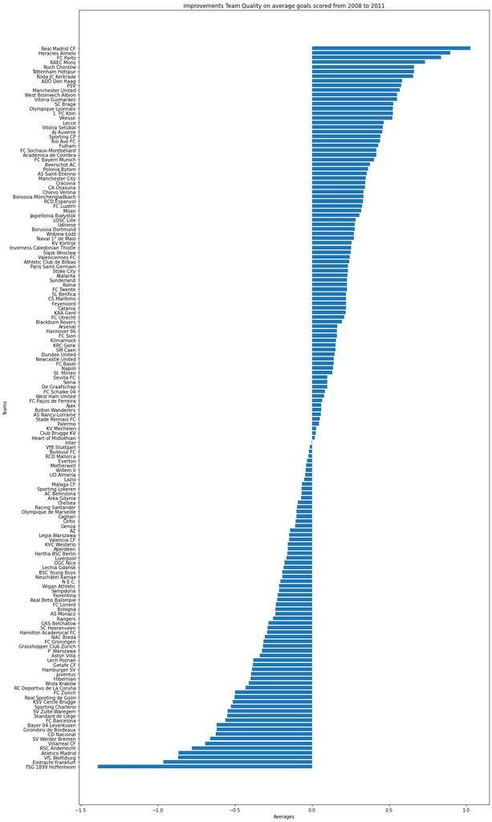

```python
fig, ax = plt.subplots(figsize=(15, 25))

# plot a horizontal bar
plt.barh(range(0,len(sorted_index)), diff_match_2011_2008.sort_values())

# Set the position of the y ticks
ax.set_yticks(range(0,len(sorted_index)))

# Set the position of the y ticks labels
ax.set_yticklabels(sorted_index)

# Set the y axis label
ax.set_ylabel('Teams')

# Set the chart's title
ax.set_title('Improvements Team Quality on average goals scored from 2008 to 2011')

# Set the y axis label
plt.xlabel("Averages")

plt.tight_layout();
```

### Research Question 2 (Which players had the most penalties?)

```python
df_player_att.head()
```

|  | id_x | player_fifa_api_id_x | player_api_id | date | overall_rating | potential | preferred_foot | attacking_work_rate | defensive_work_rate | crossing | finishing | heading_accuracy | short_passing | volleys | dribbling | curve | free_kick_accuracy | long_passing | ball_control | acceleration | sprint_speed | agility | reactions | balance | shot_power | jumping | stamina | strength | long_shots | … |
| --- | --- | --- | --- | --- | --- | --- | --- | --- | --- | --- | --- | --- | --- | --- | --- | --- | --- | --- | --- | --- | --- | --- | --- | --- | --- | --- | --- | --- | --- | --- |
| 0 | 1 | 218353 | 505942 | 2016-02-18 00:00:00 | 67.0 | 71.0 | right | medium | medium | 49.0 | 44.0 | 71.0 | 61.0 | 44.0 | 51.0 | 45.0 | 39.0 | 64.0 | 49.0 | 60.0 | 64.0 | 59.0 | 47.0 | 65.0 | 55.0 | 58.0 | 54.0 | 76.0 | 35.0 | … |
| 1 | 2 | 218353 | 505942 | 2015-11-19 00:00:00 | 67.0 | 71.0 | right | medium | medium | 49.0 | 44.0 | 71.0 | 61.0 | 44.0 | 51.0 | 45.0 | 39.0 | 64.0 | 49.0 | 60.0 | 64.0 | 59.0 | 47.0 | 65.0 | 55.0 | 58.0 | 54.0 | 76.0 | 35.0 | … |
| 2 | 3 | 218353 | 505942 | 2015-09-21 00:00:00 | 62.0 | 66.0 | right | medium | medium | 49.0 | 44.0 | 71.0 | 61.0 | 44.0 | 51.0 | 45.0 | 39.0 | 64.0 | 49.0 | 60.0 | 64.0 | 59.0 | 47.0 | 65.0 | 55.0 | 58.0 | 54.0 | 76.0 | 35.0 | … |
| 3 | 4 | 218353 | 505942 | 2015-03-20 00:00:00 | 61.0 | 65.0 | right | medium | medium | 48.0 | 43.0 | 70.0 | 60.0 | 43.0 | 50.0 | 44.0 | 38.0 | 63.0 | 48.0 | 60.0 | 64.0 | 59.0 | 46.0 | 65.0 | 54.0 | 58.0 | 54.0 | 76.0 | 34.0 | … |
| 4 | 5 | 218353 | 505942 | 2007-02-22 00:00:00 | 61.0 | 65.0 | right | medium | medium | 48.0 | 43.0 | 70.0 | 60.0 | 43.0 | 50.0 | 44.0 | 38.0 | 63.0 | 48.0 | 60.0 | 64.0 | 59.0 | 46.0 | 65.0 | 54.0 | 58.0 | 54.0 | 76.0 | 34.0 | … |

```python
df_player_att.groupby(['player_name'])['penalties'].sum().sort_values(ascending=False)[:10]
```

```
player_name
Danilo            6238.0
Alex              6140.0
Fernando          4764.0
Douglas           4687.0
Josue             4671.0
Rafinha           4633.0
Alessio Cerci     4314.0
Carlos Eduardo    4306.0
Maicon            4263.0
Diego             4259.0
Name: penalties, dtype: float64
```

### Research Question 3 (Which Goalkeeper is likely to keep clean sheets?)

```python
df_clean_sheets = df_player_att.groupby(['player_name'])['gk_reflexes'].mean().sort_values(ascending=False)[:10]
```

```python
df_clean_sheets
```

```
player_name
Iker Casillas      90.954545
Hugo Lloris        87.333333
Petr Cech          86.909091
Diego Alves        86.666667
Carlos Kameni      86.500000
Vincent Enyeama    86.466667
Victor Valdes      86.318182
Manuel Neuer       86.310345
Rene Adler         85.966667
Joe Hart           85.405405
Name: gk_reflexes, dtype: float64
```

```python
# get the indes of clean_sheets
sv = df_clean_sheets.sort_values().index
```

### Plot the bar plot showing goalkeepers with clean sheets

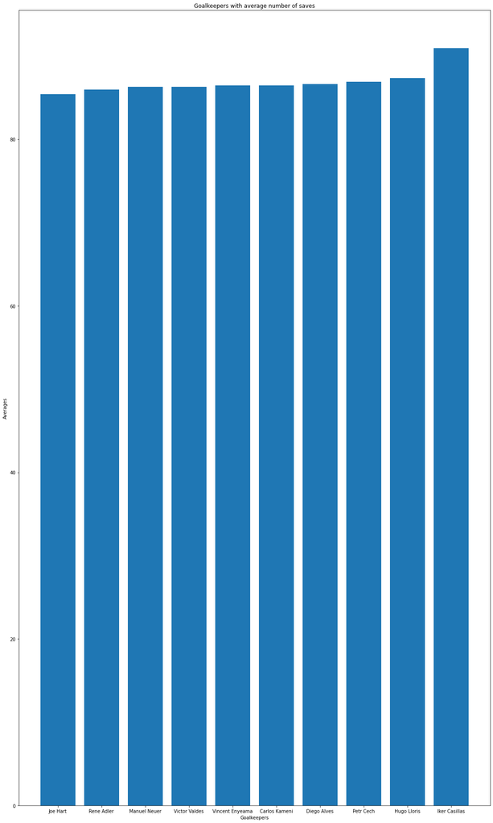

```python
fig, ax = plt.subplots(figsize=(15, 25))

# plot a horizontal bar
plt.bar(range(0,len(sv)), df_clean_sheets.sort_values())


# Set the position of the y ticks
ax.set_xticks(range(0,len(sv)))

# Set the position of the y ticks labels
ax.set_xticklabels(sv)

# Set the y axis label
ax.set_ylabel('Averages')

# Set the chart's title
ax.set_title('Goalkeepers with average number of saves')

# Set the x axis label
plt.xlabel("Goalkeepers")

plt.tight_layout();
```

#### Observation

- Iker Casillas has the highest number of saves on average.

### Research Question 4 (Which Player is more likely to convert a set piece?)

```python
df_set_piece = df_player_att.groupby(['player_name'])['free_kick_accuracy'].mean().sort_values(ascending=False)[:10]
df_set_piece
```

```
player_name
Andrea Pirlo               90.488889
David Beckham              90.071429
Juninho Pernambucano,20    89.315789
Sejad Salihovic            87.880000
Juan Arango                87.666667
Ronaldinho                 87.280000
Wesley Sneijder            87.218750
Xavi Hernandez             86.681818
Francesco Lodi             86.571429
Hakan Calhanoglu           86.393939
Name: free_kick_accuracy, dtype: float64
```

```python
# get the index of set pieces
dv = df_set_piece.index
```

### Plot a line plot of players showing freekick accuracy averages

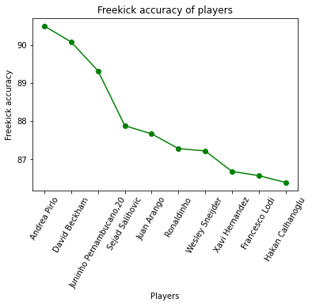

```python
# plot a line chart
plt.plot(dv, df_set_piece, 'o-g')

# set axis titles
plt.xlabel("Players")
plt.ylabel("Freekick accuracy")

# rotate axis labels
plt.xticks(rotation = 60)

# set chart title
plt.title("Freekick accuracy of players")
plt.show()
```

### Research Question 5 (How many matches was played per season?)

```python
# get the matches played in each season
df = df_matches.season.value_counts().sort_values(ascending=True)
df_md = df.to_frame(name='matches')
```

```python
# get index of the dataframe
md_index = df_md.index
```

### Lineplot to show number of matches played per season

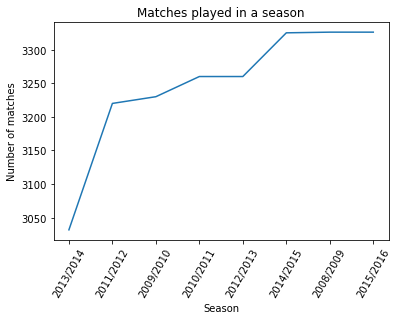

```python
# plot a line chart
plt.plot(md_index, df)

# set axis titles
plt.xlabel("Season")
plt.ylabel("Number of matches")

# rotate axis labels
plt.xticks(rotation = 60)

# set chart title
plt.title("Matches played in a season")
plt.show()
```

### Research Question 6 (What condition is a team likely to score a goal?)

```python
# number of matches that were tied/ away team win/ home team win
match_leagues_results = df_matches.groupby('match_outcome')['home_team_goal'].count()
match_leagues_results
```

```
match_outcome
Away     7466
Home    11917
Tie      6596
Name: home_team_goal, dtype: int64
```

```python
# number of matches that were tied/ away team win/ home team win
match_leagues_results1 = df_matches.groupby('match_outcome')['away_team_goal'].count()
match_leagues_results1
```

```
match_outcome
Away     7466
Home    11917
Tie      6596
Name: away_team_goal, dtype: int64
```

## Limitations

- There are some limitations listed below to the analysis which arise due the data in question.
- There are lot of columns in the tables for example Match table has 115 columns and 407395 missing values. The columns are related to betting.
- The Team table had some duplicated values. I found 3 teams having the same fifa_id and team_name. Grouping by fifa_id and team_name found the duplicated rows.
- The Players attribute table had a lot of columns with null values. I decide to drop them as they won't impact my analysis.
- Lastly, the columns had no proper documentation.

## Conclusions

- What teams improved the most over the time period?

  > Based on the years 2008 and 2011 the most improved teams over the period by looking at the average away and home goals are 'Real Madrid', 'Hercales Almelo', 'FC Porto', 'RAEC Mons', 'Ruch Chorzow'.
- Which players had the most penalties?

  > Danilo and Alex are the most penalty scorer in total.
- How many matches was played per season?

  > Andrea Pirlo is more likely to convert a set piece
- What condition is a team likely to score a goal?

  > Based on the above analysis a team is more likely to score a goal when they are playing in their Home ground and less likely when playing away from home